# RBiips: Bayesian inference in nonlinear non-Gaussian hidden Markov model

In this tutorial, we consider applying sequential Monte Carlo methods for Bayesian inference in a nonlinear non-Gaussian hidden Markov model.

## Statistical model

The statistical model is defined as follows.

\[ x_1\sim \mathcal N\left (\mu_0, \frac{1}{\lambda_0}\right ) \]

\[ y_1\sim \mathcal N\left (h(x_1), \frac{1}{\lambda_y}\right ) \]

For \( t=2:t_{max} \)

\[ x_t|x_{t-1} \sim \mathcal N\left ( f(x_{t-1},t-1), \frac{1}{\lambda_x}\right ) \]

\[ y_t|x_t \sim \mathcal N\left ( h(x_{t}), \frac{1}{\lambda_y}\right ) \]

## Statistical model in BUGS language

One needs to describe the model in BUGS language. We create the file 'hmm_1d_nonlin.bug':

```
var x_true[t_max], x[t_max], y[t_max]

data
{
  x_true[1] ~ dnorm(mean_x_init, prec_x_init)
  y[1] ~ dnorm(x_true[1]^2/20, prec_y)
  for (t in 2:t_max)
  {
    x_true[t] ~ dnorm(0.5*x_true[t-1]+25*x_true[t-1]/(1+x_true[t-1]^2)+8*cos(1.2*(t-1)), prec_x)
    y[t] ~ dnorm(x_true[t]^2/20, prec_y)
  }
}

model
{
  x[1] ~ dnorm(mean_x_init, prec_x_init)
  y[1] ~ dnorm(x[1]^2/20, prec_y)
  for (t in 2:t_max)
  {
    x[t] ~ dnorm(0.5*x[t-1]+25*x[t-1]/(1+x[t-1]^2)+8*cos(1.2*(t-1)), prec_x)
    y[t] ~ dnorm(x[t]^2/20, prec_y)
  }
}
```

## Installation of RBiips package

Install *RBiips* package archive depending on your system:

- `RBiips_x.x.x.zip` for Windows
- `RBiips_x.x.x.tgz` for Mac OS X
- `RBiips_x.x.x.tar.gz` for Linux

```r
install.packages('path/to/RBiips_x.x.x.ext')
```

where `x.x.x` is the version of the package and `ext` is the archive extension for your system.

**Note:** Linux installation needs a previous installation of *BiiPS* libraries and headers as well as *Boost*.

## Load model and data

**Model parameters**

```r
t_max = 20
mean_x_init = 0
prec_x_init = 1/5
prec_x = 1/10
prec_y = 1
data = list(t_max=t_max, prec_x_init=prec_x_init,
            prec_x=prec_x, prec_y=prec_y, mean_x_init=mean_x_init)
```

**Load RBiips package**

```r
require(RBiips)
```

**Compile BUGS model and sample data**

```r
model_file = 'hmm_1d_nonlin.bug' # BUGS model filename
sample_data = TRUE # Boolean
model = biips.model(model_file, data, sample.data=sample_data) # Create biips model and sample data
```

```
* Parsing model in: hmm_1d_nonlin.bug
* Compiling data graph
  Declaring variables
  Graph size: 279
  Sampling data
  Reading data back into data table
  Declaring variables
  Graph size: 280
```

```r
data = model$data()
```

## BiiPS Sequential Monte Carlo

Let now use *BiiPS* to run a particle filter.

**Parameters of the algorithm**. We want to monitor the variable x, and to get the filtering and smoothing particle approximations. The algorithm will use 10000 particles, stratified resampling, with a threshold of 0.5.

```r
n_part = 10000 # Number of particles
variables = c('x') # Variables to be monitored
type = 'fs'; rs_type = 'stratified'; rs_thres = 0.5 # Optional parameters
```

**Run SMC**

```r
out_smc = smc.samples(model, variables, n_part,
                      type=type, rs.type=rs_type, rs.thres=rs_thres)
```

```
* Assigning node samplers
* Running SMC forward sampler with 10000 particles
  |**************************************************| 20 iterations in 1.40 s
```

**Diagnostic on the algorithm**

```r
diagnostic(out_smc$x)
```

```
$filtering
diagnostic: GOOD

$smoothing
diagnostic: GOOD
```

**Summary statistics**

```r
summ = summary(out_smc$x, fun=c('mean', 'median', 'quantiles'),
               probs=c(.025, .975))
```

**Plot Filtering estimates**

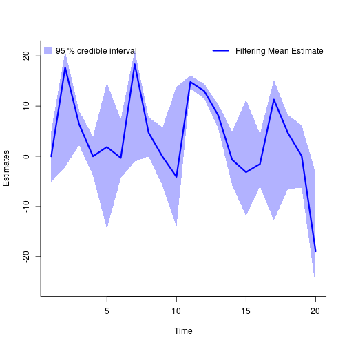

```r
x_f_mean = summ$f$Mean
x_f_med = summ$f$Med
x_f_inf = summ$f$'Qu. 0.025'
x_f_sup = summ$f$'Qu. 0.975'

plot(x_f_mean, type='l', col=4, lwd=3,
     xlab='Time', ylab='Estimates',
     ylim=c(min(x_f_inf), max(x_f_sup)))
legend('topright', leg='Filtering Mean Estimate',
       col=4, lwd=3, bty='n')

lightcols = adjustcolor(palette('default'), alpha.f=.3)
palette(lightcols)
polygon(c(1:t_max, t_max:1), c(x_f_inf, rev(x_f_sup)),
        col=4, border=NA)
legend('topleft', leg='95 % credible interval',
       col=4, pch=15, pt.cex=2, bty='n')
palette('default')
```

**Plot Smoothing estimates**

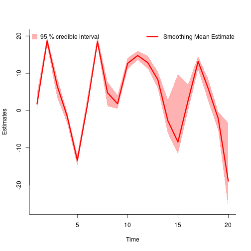

```r
x_s_mean = summ$s$Mean
x_s_med = summ$s$Med
x_s_inf = summ$s$'Qu. 0.025'
x_s_sup = summ$s$'Qu. 0.975'

plot(x_s_mean, type='l', col=2, lwd=3,
     xlab='Time', ylab='Estimates',
     ylim=c(min(x_s_inf), max(x_s_sup)))
legend('topright', leg='Smoothing Mean Estimate',
       col=2, lwd=3, bty='n')

palette(lightcols)
polygon(c(1:t_max, t_max:1), c(x_s_inf, rev(x_s_sup)),
        col=2, border=NA)
legend('topleft', leg='95 % credible interval',
       col=2, pt.cex=2, pch=15, bty='n')
palette('default')
```

**Marginal filtering and smoothing densities**

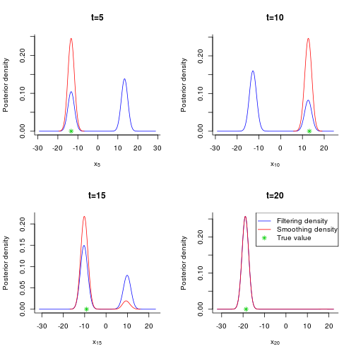

```r
kde_estimates = density(out_smc$x)
time_index = c(5, 10, 15, 20)
par(mfrow=c(2,2))
for (k in 1:length(time_index)) {
  tk = time_index[k]
  plot(kde_estimates[[tk]], col=c(4,2), lty=1,
       xlab=bquote(x[.(tk)]), ylab='Posterior density',
       main=paste('t=', tk, sep=''), sub='',
       legend.text=FALSE)
  points(data$x_true[tk], 0, col=3, pch=8)
}
legend('topright', leg=c('Filtering density', 'Smoothing density', 'True value'),
       col=c(4, 2, 3), pch=c(NA,NA,8), lty=c(1,1,NA), bg='white')
par(mfrow=c(1,1))
```

## BiiPS Particle Independent Metropolis-Hastings

We now use *BiiPS* to run a Particle Independent Metropolis-Hastings.

**Parameters of the PIMH**

```r
n_burn = 500
n_iter = 500
thin = 1
n_part = 100
```

**Run PIMH**

```r
pimh.update(model, variables, n.iter=n_burn, n.part=n_part) # burn-in iterations
```

```
* Initializing PIMH
* Updating PIMH with 100 particles
  |**************************************************| 500 iterations in 4.12 s
```

```r
out_pimh = pimh.samples(model, variables, n_iter, n_part, thin=thin)
```

```
* Generating PIMH samples with 100 particles
  |**************************************************| 500 iterations in 4.18 s
```

**Some summary statistics**

```r
require(rjags)
summary_pimh = summary(as.mcmc.list(out_pimh$x), quantiles=c(.025, .975))
```

**Posterior mean and quantiles**

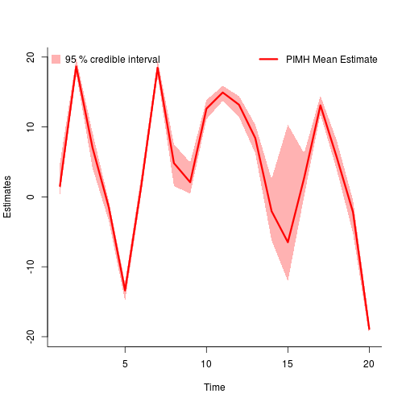

```r
x_pimh_mean = summary_pimh$statistics[,'Mean']
x_pimh_inf = summary_pimh$quantiles[,1]
x_pimh_sup = summary_pimh$quantiles[,2]
plot(x_pimh_mean, lwd=3, type='l', col=2,
     xlab='Time', ylab='Estimates',
     ylim=c(min(x_pimh_inf), max(x_pimh_sup)))
legend('topright', leg='PIMH Mean Estimate',
       col=2, lwd=3, bty='n')

palette(lightcols)
polygon(c(1:t_max, t_max:1), c(x_pimh_inf, rev(x_pimh_sup)),
        col=2, border=NA)
legend('topleft', leg='95 % credible interval',
       col=2, pch=15, pt.cex=2, bty='n')
palette('default')
```

**Trace of MCMC samples**

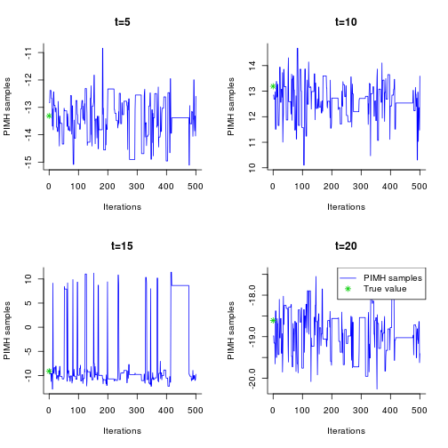

```r
time_index = c(5, 10, 15, 20)
par(mfrow=c(2,2))
for (k in 1:length(time_index)) {
  tk = time_index[k]
  plot(out_pimh$x[tk,], col=4, type='l',
       xlab='Iterations', ylab='PIMH samples',
       main=paste('t=', tk, sep=''))
  points(0, data$x_true[tk], col=3, pch=8)
}
legend('topright', leg=c('PIMH samples', 'True value'),
       col=c(4, 3), pch=c(NA,8), lty=c(1,NA), bg='white')
```

**Histograms of posteriors**

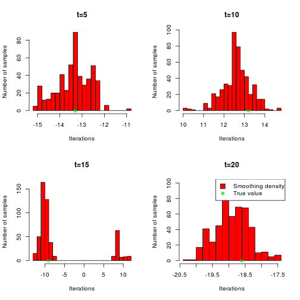

```r
par(mfrow=c(2,2))
for (k in 1:length(time_index)) {
  tk = time_index[k]
  hist(out_pimh$x[tk,], breaks=20, col=2,
       xlab='Iterations', ylab='Number of samples',
       main=paste('t=', tk, sep=''))
  points(data$x_true[tk], 0, col=3, pch=8)
}
legend('topright', leg=c('Smoothing density', 'True value'),
       col=c(1, 3), pch=c(22,8), lwd=1, lty=NA, pt.cex=c(2,1), pt.bg=c(2,NA),
       bg='white')
```

**Kernel density estimates of posteriors**

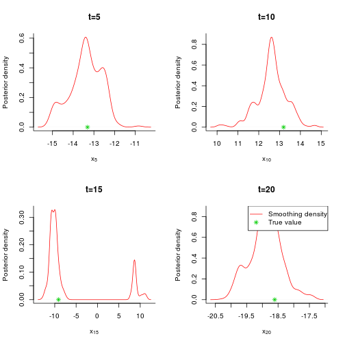

```r
par(mfrow=c(2,2))
for (k in 1:length(time_index)) {
  tk = time_index[k]
  kde_estimate_pimh = density(out_pimh$x[tk,])
  plot(kde_estimate_pimh, col=2,
       xlab=bquote(x[.(tk)]), ylab='Posterior density',
       main=paste('t=', tk, sep=''))
  points(data$x_true[tk], 0, col=3, pch=8)
}
legend('topright', leg=c('Smoothing density', 'True value'),
       col=c(2, 3), pch=c(NA,8), lty=c(1,NA), bg='white')
par(mfrow=c(1,1))
```